# Propagation of Neural Networks

2026-03-12

## 1 Non-linear Poisson Regression

In this architecture, we extend the standard Poisson GLM by introducing a hidden layer with $m$ units. This allows the model to learn non-linear combinations of the inputs before predicting the rate parameter $\lambda$.

### 1.1 1. Mathematical Description

The model assumes the response variable $y$ follows a Poisson distribution: $y \sim \text{Poisson}(\lambda)$.

#### 1.1.1 **The Forward Pass**

1. **Hidden Layer (Linear):** $\eta_k = \sum_{i=1}^{p} \beta_{ki} x_i + b_{1,k}$
2. **Activation:** $a_k = \exp(\eta_k)$
3. **Output Layer:** $\lambda = \sum_{k=1}^{m} w_k a_k + b_2$
4. **Poisson Loss:** $L = \lambda - y \ln(\lambda)$

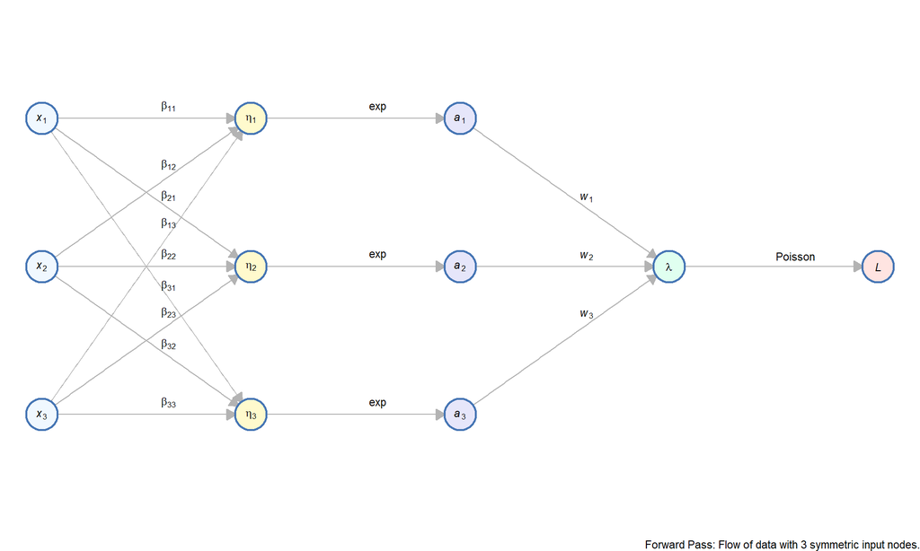

### 1.2 2. Computational Gradient Graph

In the gradient network, we compute the partial derivatives. The gradient for the hidden weight $\beta_{ki}$ is:
$$\frac{\partial L}{\partial \beta_{ki}} = x_i
\cdot \exp(\eta_k) \cdot w_k \cdot \frac{\lambda -
y}{\lambda}$$

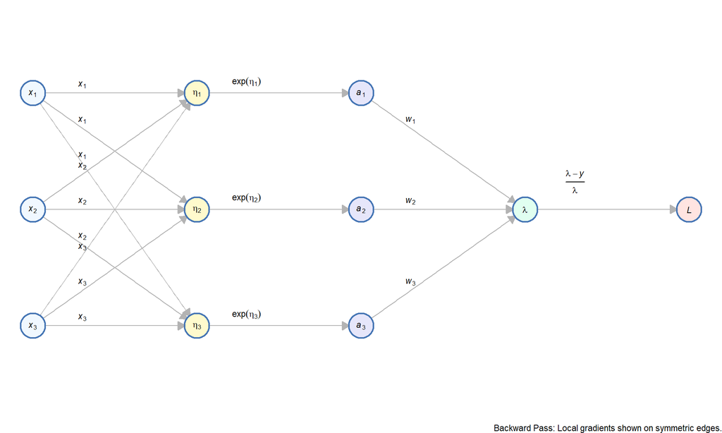

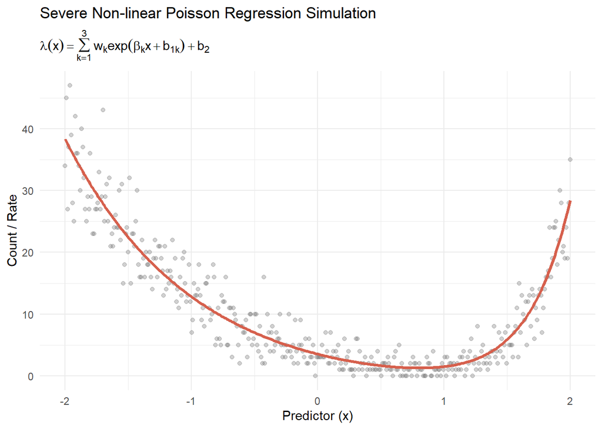

## 2 Neural Network: Forward and Backward Computational Graphs

### 2.1 1. The Forward Pass: Computing $L$ from $x$

In the forward pass, information flows from the inputs to the loss. The edges represent the **parameters** (weights) and **functions** that transform the data.

#### 2.1.1 Mathematical Description

For a single observation:

1. **Layer 1:** $\eta = \mathbf{B}x + b_1 \rightarrow h = \tanh(\eta)$
2. **Layer 2:** $\zeta = \mathbf{A}h + b_2 \rightarrow a = \tanh(\zeta)$
3. **Output:** $\mu = w^T a + b_3$
4. **Loss:** $L = \frac{(y - \mu)^2}{2\sigma^2}$ (Gaussian Negative Log-Likelihood)

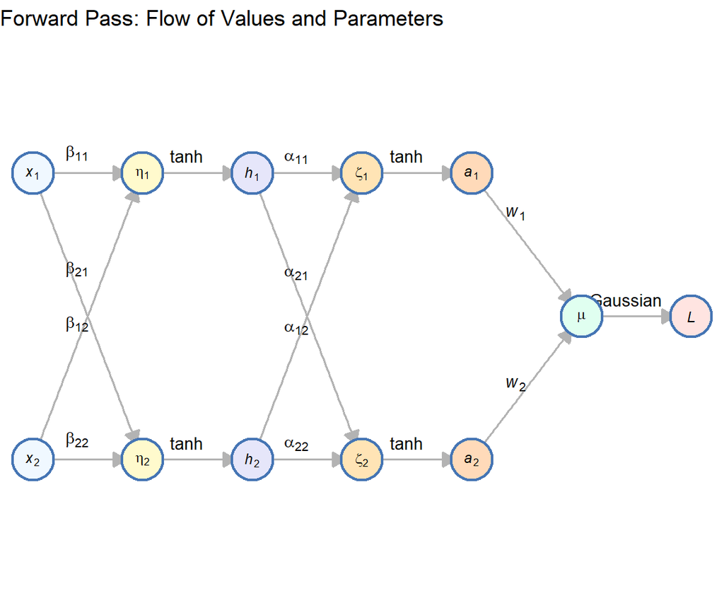

### 2.2 2. The Backward Pass: Gradient Network

#### 2.2.1 The “Sum of Paths” Rule

To find $\frac{\partial L}{\partial h_j}$, we sum the branches going into the next layer:
$$\frac{\partial L}{\partial h_j} = \sum_{k} \left(
\frac{\partial \zeta_k}{\partial h_j} \cdot \frac{\partial L}{\partial
\zeta_k} \right)$$

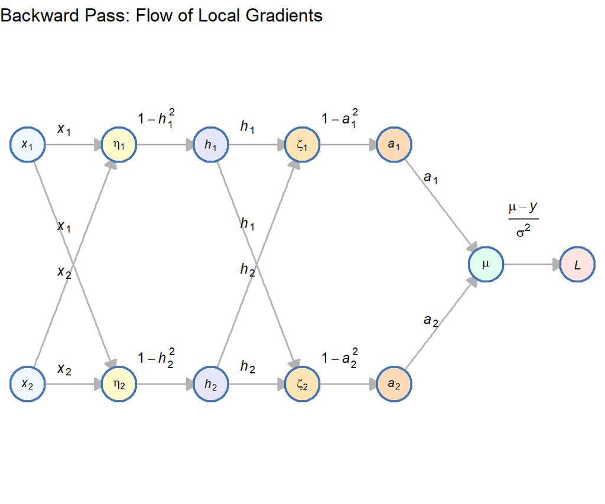